# Detecting cell-cycle stage difference in glioblastoma cells

Donghyung Lee

2018-05-03

Here, we illustrate how to use the iasva package to detect cell cycle stage difference within single cell RNA sequencing data. We use single cell RNA sequencing (scRNA-Seq) data obtained from human glioblastoma samples ([Petel et. al., 2014](https://www.ncbi.nlm.nih.gov/pmc/articles/PMC4123637/)). This dataset is included in a R data package (“iasvaExamples”) containing data examples for IA-SVA (https://github.com/dleelab/iasvaExamples). To install the package, follow the instruction provided in the GitHub page.

## Install packages

```r
#devtools
library(devtools)
#iasva
devtools::install_github("UcarLab/iasva")
#iasvaExamples
devtools::install_github("dleelab/iasvaExamples")
```

## Load packages

```r
rm(list=ls())
library(irlba) # partial SVD, the augmented implicitly restarted Lanczos bidiagonalization algorithm
library(iasva)
library(iasvaExamples)
library(sva)
library(SCnorm)
library(scran)
library(scater)
library(Rtsne)
library(pheatmap)
library(corrplot)
library(DescTools) #pcc i.e., Pearson's contingency coefficient
library(RColorBrewer)
library(SummarizedExperiment)
library(vioplot)
color.vec <- brewer.pal(3, "Set1")

# Normalization.
normalize <- function(counts)
{
    normfactor <- colSums(counts)
    return(t(t(counts)/normfactor)*median(normfactor))
}
```

## Load the glioblastoma single cell RNA-Seq data

```r
data("Patel_Glioblastoma_scRNAseq_Read_Counts")
data("Patel_Glioblastoma_scRNAseq_Annotations")
data("Patel_Glioblastoma_scRNAseq_ENSG_ID")
ls()
```

```
## [1] "color.vec"
## [2] "normalize"
## [3] "Patel_Glioblastoma_scRNAseq_Annotations"
## [4] "Patel_Glioblastoma_scRNAseq_ENSG_ID"
## [5] "Patel_Glioblastoma_scRNAseq_Read_Counts"
```

```r
counts <- Patel_Glioblastoma_scRNAseq_Read_Counts
anns <- Patel_Glioblastoma_scRNAseq_Annotations
ENSG.ID <- Patel_Glioblastoma_scRNAseq_ENSG_ID
dim(anns)
```

```
## [1] 434   3
```

```r
dim(counts)
```

```
## [1] 25353   434
```

```r
length(ENSG.ID)
```

```
## [1] 25353
```

```r
summary(anns)
```

```
##          run      patient_id     subtype
##  SRR1294493:  1   MGH26:118   None   :120
##  SRR1294494:  1   MGH28: 95   Mes    :103
##  SRR1294496:  1   MGH29: 76   Pro    : 89
##  SRR1294498:  1   MGH30: 74   Cla    : 46
##  SRR1294499:  1   MGH31: 71   Neu    : 24
##  SRR1294500:  1               Pro+Cla: 20
##  (Other)   :428               (Other): 32
```

```r
table(anns$patient_id, anns$subtype)
```

```
##
##         Cla Cla+Mes Mes Neu Neu+Cla Neu+Mes None Pro Pro+Cla Pro+Neu
##   MGH26  10       0   0   1       1       0   19  71      14       2
##   MGH28   1       5  56   0       0       7   21   5       0       0
##   MGH29   0       0  28  12       0      12   19   4       0       1
##   MGH30  33       1   8   1       1       0   16   6       6       2
##   MGH31   2       0  11  10       0       0   45   3       0       0
```

```r
ContCoef(table(anns$patient_id, anns$subtype))
```

```
## [1] 0.723431
```

The annotations describing the glioblastoma samples and experimental settings are stored in “anns” and the read counts information is stored in “counts”.

## Extract glioblastoma cells from Patient MGH30

We use read counts of glioblastoma cells from Patient MGH30 (n = 74).

```r
counts <- counts[, (anns$patient_id=="MGH30")]
anns <- subset(anns, (patient_id=="MGH30"))
dim(counts)
```

[1] 25353 74

```r
dim(anns)
```

[1] 74 3

```r
anns <- droplevels(anns)
prop.zeros <- sum(counts==0)/length(counts)
prop.zeros
```

[1] 0.6290769

```r
# filter out genes that are sparsely and lowly expressed
filter = apply(counts, 1, function(x) length(x[x>5])>=3)
counts = counts[filter,]
dim(counts)
```

[1] 21907 74

```r
ENSG.ID <- ENSG.ID[filter]
length(ENSG.ID)
```

[1] 21907

```r
prop.zeros <- sum(counts==0)/length(counts)
prop.zeros
```

[1] 0.5731686

```r
Subtype <- anns$subtype
Patient_ID <- anns$patient_id
mito.genes <- grep(pattern = "^MT-", x = rownames(x = counts), value = TRUE)
Percent_Mito <- colSums(counts[mito.genes, ])/colSums(counts)
```

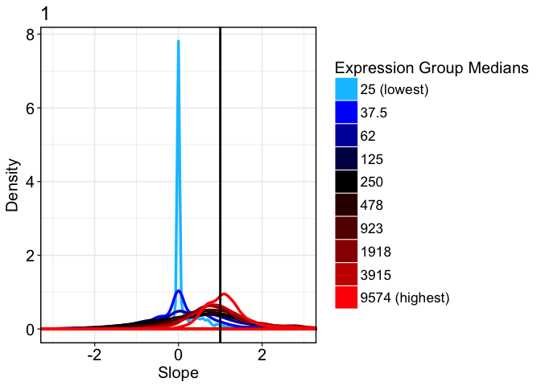

```r
## Normalization using SCnorm
## count-depth relationship for all genes
Conditions = rep(c(1), each=74)
countDeptEst <- plotCountDepth(Data = counts, Conditions = Conditions,
                               FilterCellProportion = .1, NCores=3)
```

```r
DataNorm <- SCnorm(Data = counts, Conditions = Conditions,
                   PrintProgressPlots = FALSE,
                   FilterCellNum = 10,
                   NCores=3)
```

```
## Setting up parallel computation using 3 cores
```

```
## Gene filter is applied within each condition.
```

```
## 5275 genes in condition 1 will not be included in the normalization due to
##              the specified filter criteria.
```

```
## A list of these genes can be accessed in output,
##     see vignette for example.
```

```
## Finding K for Condition 1
```

```
## Trying K = 1
```

```
## Trying K = 2
```

```
## Trying K = 3
```

```
## Trying K = 4
```

```
## Trying K = 5
```

```
## Trying K = 6
```

```
## Trying K = 7
```

```
## Done!
```

```r
counts <- results(DataNorm)
summary(colSums(counts))
```

```
##      Min.   1st Qu.    Median      Mean   3rd Qu.      Max.
##  54112972  56272666  56519431  58933473  57764297 116031129
```

```r
dim(counts)
```

```
## [1] 21907    74
```

## Calculate the number of detected genes

It is well known that the number of detected genes in each cell explains a very large portion of variability in scRNA-Seq data ([Hicks et. al. 2015 BioRxiv](http://biorxiv.org/content/early/2015/08/25/025528), [McDavid et. al. 2016 Nature Biotechnology](http://www.nature.com/nbt/journal/v34/n6/full/nbt.3498.html)). Frequently, the first principal component of log-transformed scRNA-Seq read counts is highly correlated with the number of detected genes (e.g., r > 0.9). Here, we calculate the number of detected genes for glioblastoma cells, which will be used as an known factor in the IA-SVA analyses.

```r
Num_Detected_Genes <- colSums(counts>0)
Geo_Lib <- colSums(log(counts+1))
summary(Geo_Lib)
```

```
##    Min. 1st Qu.  Median    Mean 3rd Qu.    Max.
##   48594   55663   60062   60197   62882   99461
```

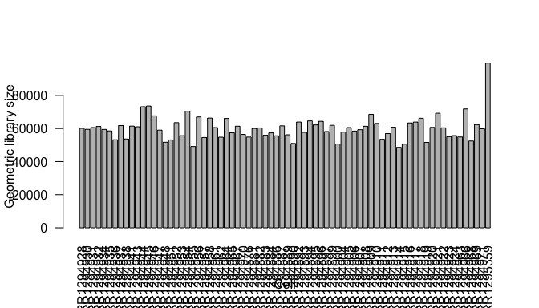

```r
barplot(Geo_Lib, xlab="Cell", las=2, ylab = "Geometric library size")
```

```r
lcounts <- log(counts + 1)
# PC1 and Geometric library size correlation
pc1 = irlba(lcounts - rowMeans(lcounts), 1)$v[,1] ## partial SVD
cor(Num_Detected_Genes, pc1)
```

```
## [1] -0.8357149
```

```r
cor(Geo_Lib, pc1)
```

```
## [1] -0.9299861
```

## Run IA-SVA

Here, we run IA-SVA using Geo_Lib_Size as a known factor and identify five hidden factors. SVs are plotted in a pairwise fashion to uncover which SVs can seperate cells.

```r
set.seed(3445)
mod <- model.matrix(~Geo_Lib)
summ_exp <- SummarizedExperiment(assays = counts)
iasva.res<- iasva(summ_exp, mod[,-1],verbose=FALSE, permute=FALSE, num.sv=5)
```

```
## IA-SVA running...
## SV1 Detected!
## SV2 Detected!
## SV3 Detected!
## SV4 Detected!
## SV5 Detected!
## # of significant surrogate variables: 5
```

```r
iasva.sv <- iasva.res$sv

Cluster <- as.factor(iasva.sv[,1] < 0.1)
levels(Cluster)=c("Cluster1","Cluster2")
table(Cluster)
```

```
## Cluster
## Cluster1 Cluster2
##       13       61
```

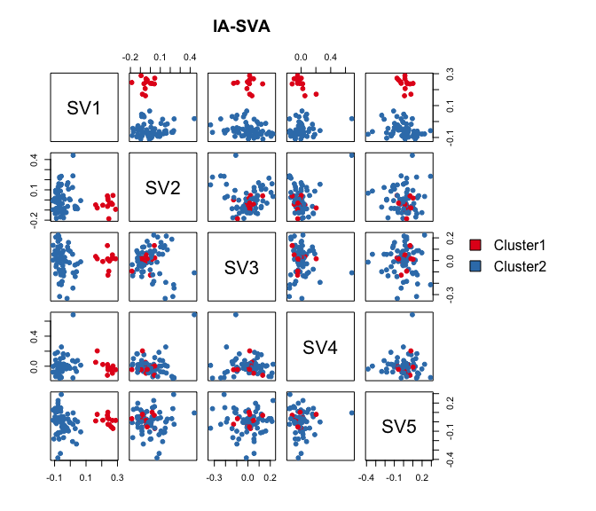

```r
pairs(iasva.sv[,1:5], main="IA-SVA", pch=21, col=color.vec[Cluster],
      bg=color.vec[Cluster], oma=c(4,4,6,14))
legend("right", levels(Cluster), fill=color.vec, bty="n")
```

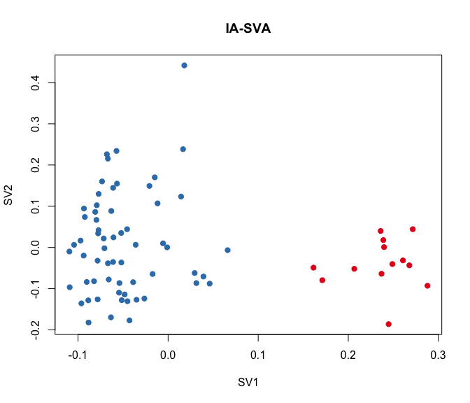

```r
plot(iasva.sv[,1:2], main="IA-SVA", pch=21, xlab="SV1", ylab="SV2",
     col=color.vec[Cluster], bg=color.vec[Cluster])
```

```r
cor(Num_Detected_Genes, iasva.sv[,1])
```

```
## [1] 0.3477167
```

```r
cor(Geo_Lib, iasva.sv[,1])
```

```
## [1] 0.4360903
```

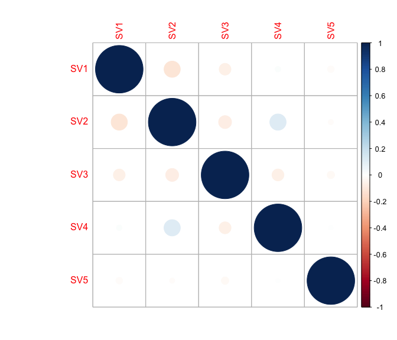

```r
corrplot(cor(iasva.sv))
```

## Find marker genes for the detected heterogeneity (SV1).

Here, using the find_markers() function we find marker genes that are significantly associated with SV1 (multiple testing adjusted p-value < 0.05, default significance cutoff, and R-squared value > 0.3).

```r
# try different R2 thresholds
pdf(paste0("Clustering_analyses_figure3_sv1.pdf"))
r2.results <- study_R2(summ_exp, iasva.sv,selected.svs=1, no.clusters=2)
```

```
## # of markers (): 466
## total # of unique markers:  466# of markers (): 361
## total # of unique markers:  361# of markers (): 232
## total # of unique markers:  232# of markers (): 165
## total # of unique markers:  165# of markers (): 119
## total # of unique markers:  119# of markers (): 89
## total # of unique markers:  89# of markers (): 62
## total # of unique markers:  62# of markers (): 47
## total # of unique markers:  47# of markers (): 33
## total # of unique markers:  33# of markers (): 21
## total # of unique markers:  21# of markers (): 14
## total # of unique markers:  14# of markers (): 5
## total # of unique markers:  5# of markers (): 1
## total # of unique markers:  1# of markers (): 0
## total # of unique markers:  0
```

```r
dev.off()
```

```r
marker.counts.SV1 <- find_markers(summ_exp,
                            as.matrix(iasva.sv[,c(1)]), rsq.cutoff = 0.4)
```

```
## # of markers (): 62
## total # of unique markers:  62
```

```r
marker.counts.SV1.long <- find_markers(summ_exp,
                              as.matrix(iasva.sv[,c(1)]), rsq.cutoff = 0.3)
```

```
## # of markers (): 119
## total # of unique markers:  119
```

```r
nrow(marker.counts.SV1)
```

```
## [1] 62
```

```r
nrow(marker.counts.SV1.long)
```

```
## [1] 119
```

```r
anno.col2 <- data.frame(Cluster=Cluster, SV1=iasva.sv[,1])
rownames(anno.col2) <- colnames(marker.counts.SV1)
head(anno.col2)
```

```
##             Cluster         SV1
## SRR1294928 Cluster2  0.03921618
## SRR1294930 Cluster2 -0.08861064
## SRR1294931 Cluster2 -0.06308121
## SRR1294932 Cluster2 -0.07956245
## SRR1294934 Cluster2  0.01656383
## SRR1294935 Cluster2 -0.04288853
```

```r
cluster.col <- color.vec[1:2]
names(cluster.col) <- as.vector(levels(Cluster))
anno.colors <- list(Cluster=cluster.col)
anno.colors
```

```
## $Cluster
##  Cluster1  Cluster2
## "#E41A1C" "#377EB8"
```

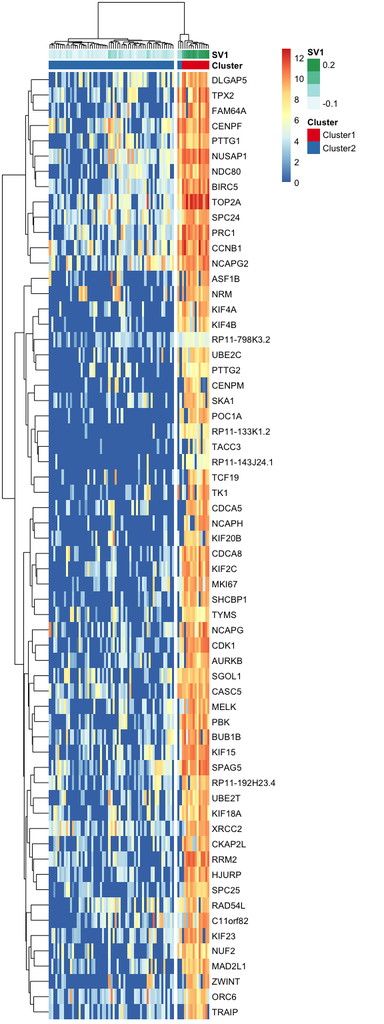

```r
pheatmap(log(marker.counts.SV1+1), show_colnames =FALSE,
         clustering_method = "ward.D2",cutree_cols = 2,annotation_col = anno.col2,
         annotation_colors = anno.colors)
```

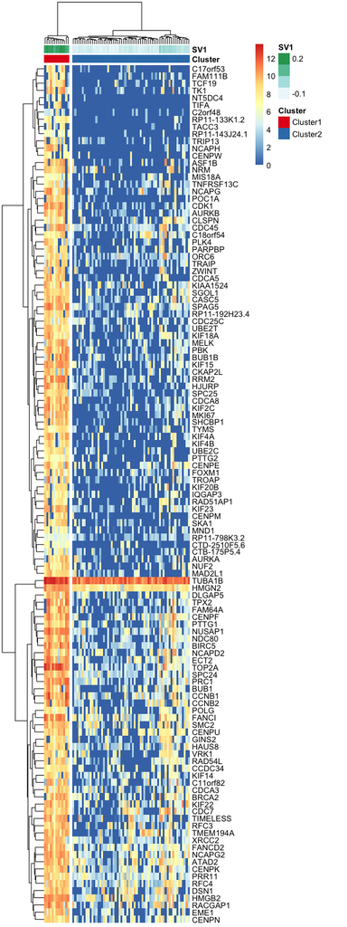

```r
pheatmap(log(marker.counts.SV1.long+1), show_colnames =FALSE,
         clustering_method = "ward.D2",cutree_cols = 2,annotation_col = anno.col2,
         annotation_colors = anno.colors)
```

```r
gene.list <- rownames(marker.counts.SV1)
write.table(gene.list, file = paste0("CC_genes.short.txt"),
            col.names =F, row.names = F, quote = F)

gene.list <- rownames(marker.counts.SV1.long)
write.table(gene.list, file = paste0("CC_genes.long.txt"),
            col.names =F, row.names = F, quote = F)
```

Theses marker genes are strongly enriched in cell-cycle related GO terms and KEGG pathways. (See Supplementary Figure 6 in https://doi.org/10.1101/151217)

## Cell type assignment using scran R package

```r
ENSG.counts <- counts
rownames(ENSG.counts) <- ENSG.ID
sce <- SingleCellExperiment(list(counts=ENSG.counts))

# load human cell cycle markers
hs.pairs <- readRDS(system.file("exdata",
                                "human_cycle_markers.rds", package="scran"))
assigned <- cyclone(sce, pairs=hs.pairs)
head(assigned$scores)
```

```
##      G1     S   G2M
## 1 0.429 0.970 0.000
## 2 0.105 0.913 0.020
## 3 0.128 0.908 0.015
## 4 0.043 0.963 0.022
## 5 0.002 0.706 0.532
## 6 0.445 0.886 0.000
```

```r
table(assigned$phases)
```

```
##
##  G1 G2M   S
##   8  13  53
```

```r
phase <- rep("S", ncol(sce))
phase[assigned$scores$G1 > 0.5 & assigned$scores$G2M < 0.5] <- "G1"
phase[assigned$scores$G1 < 0.5 & assigned$scores$G2M > 0.5] <- "G2M"
phase[assigned$scores$G1 < 0.5 & assigned$scores$G2M < 0.5] <- "S"
phase[assigned$scores$G1 > 0.5 & assigned$scores$G2M > 0.5] <- "Unknown"
table(phase)
```

```
## phase
##      G1     G2M       S Unknown
##       7      11      53       3
```

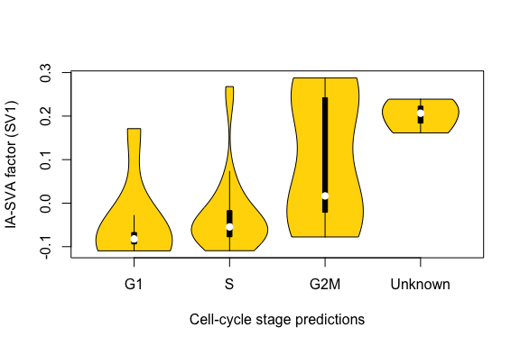

```r
G1 <- iasva.sv[,1][phase=="G1"]
S <- iasva.sv[,1][phase=="S"]
G2M <- iasva.sv[,1][phase=="G2M"]
Unknown <- iasva.sv[,1][phase=="Unknown"]
vioplot(G1, S, G2M, Unknown, names=c("G1", "S", "G2M", "Unknown"),
   col="gold")
title(xlab="Cell-cycle stage predictions", ylab="IA-SVA factor (SV1)")
```

## Run tSNE to detect the hidden heterogeneity. For comparison purposes, we applied tSNE on read counts of all genes to identify the hidden heterogeneity. We used the Rtsne R package with default settings.

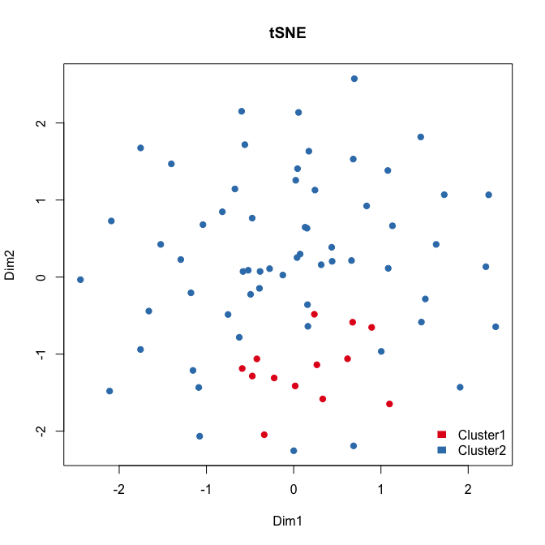

```r
set.seed(43324)
tsne.res <- Rtsne(t(lcounts), dims = 2, perplexity = 20)
plot(tsne.res$Y, main="tSNE", xlab="Dim1", ylab="Dim2",
     pch=21, col=color.vec[Cluster], bg=color.vec[Cluster], oma=c(4,4,6,12))
legend("bottomright", levels(Cluster), border="white",
       fill=color.vec, bty="n")
```

As shown above, tSNE fails to detect the outlier cells that are identified by IA-SVA when all genes are used. Same color coding is used as above.

## Run tSNE post IA-SVA analyses, i.e., run tSNE on marker genes associated with SV1 as detected by IA-SVA.

Here, we apply tSNE on the marker genes for SV1 obtained from IA-SVA

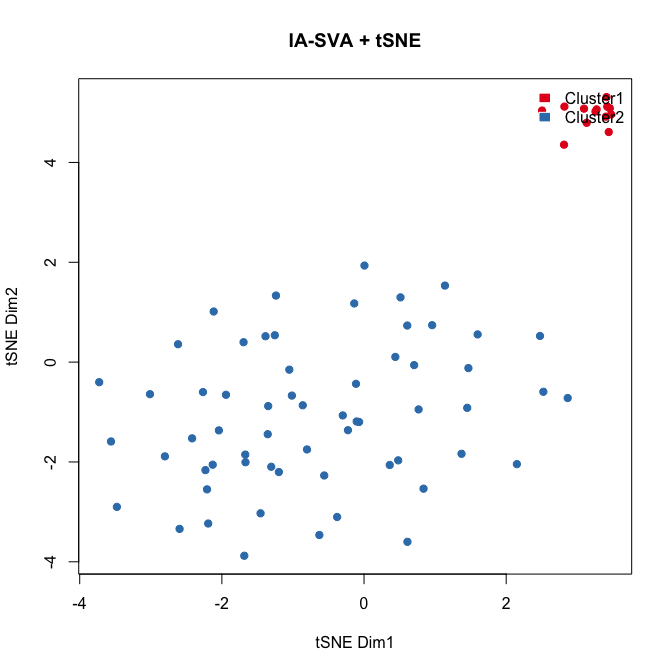

```r
set.seed(3452)
tsne.res <- Rtsne(unique(t(log(marker.counts.SV1.long+1))),
                  dims = 2, perplexity = 20)

plot(tsne.res$Y, main="IA-SVA + tSNE", xlab="tSNE Dim1",
     ylab="tSNE Dim2", pch=21, col=color.vec[Cluster],
     bg=color.vec[Cluster], oma=c(4,4,6,12))
legend("topright", levels(Cluster), border="white", fill=color.vec, bty="n")
```

## Run principal component analysis (PCA) to detect the hidden heterogeneity (SV1).

Here, we use PCA to detect the cell cycle stage difference (SV1) detected by IA-SVA.

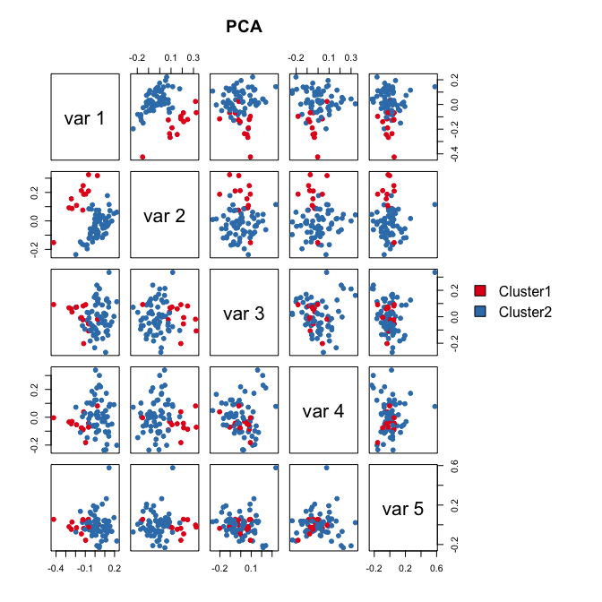

```r
set.seed(3333)
pca.res = irlba(lcounts - rowMeans(lcounts), 5)$v ## partial SVD

pairs(pca.res[,1:5], main="PCA", pch=21, col=color.vec[Cluster],
      bg=color.vec[Cluster],
      oma=c(4,4,6,14))
legend("right", levels(Cluster), fill=color.vec, bty="n")
```

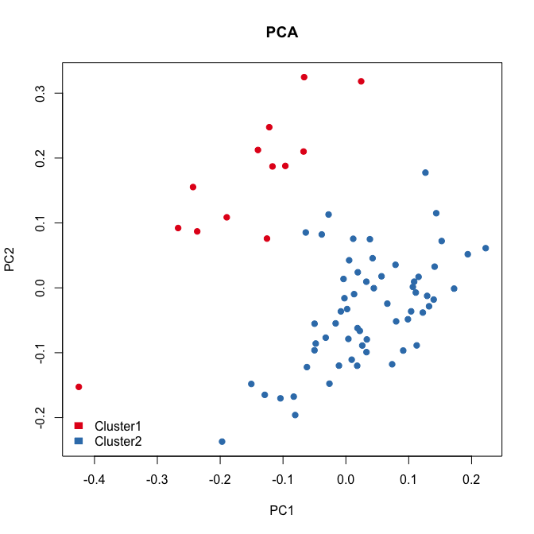

```r
plot(pca.res[,1:2], main="PCA", pch=21, xlab="PC1", ylab="PC2",
     col=color.vec[Cluster], bg=color.vec[Cluster])
legend("bottomleft", levels(Cluster), border="white", fill=color.vec, bty="n")
```

## Run surrogate variable analysis (SVA) to detect the hidden heterogeneity (SV1).

Here, for comparison purposes we use SVA to detect the hidden heterogeneity in our example data.

```r
mod1 <- model.matrix(~Geo_Lib)
mod0 <- cbind(mod1[,1])
sva.res = svaseq(counts,mod1,mod0, n.sv=5)$sv
```

```
## Number of significant surrogate variables is:  5
## Iteration (out of 5 ):1  2  3  4  5
```

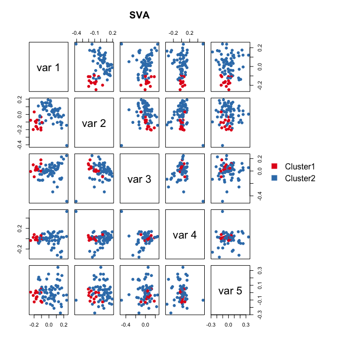

```r
pairs(sva.res[,1:5], main="SVA", pch=21, col=color.vec[Cluster],
      bg=color.vec[Cluster], oma=c(4,4,6,14))
legend("right", levels(Cluster), border="white", fill=color.vec, bty="n")
```

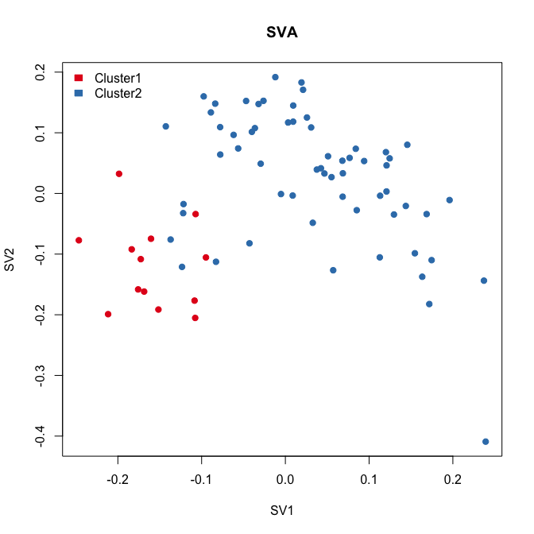

```r
plot(sva.res[,1:2], main="SVA", xlab="SV1", ylab="SV2",
     pch=21, col=color.vec[Cluster], bg=color.vec[Cluster])
legend("topleft", levels(Cluster), border="white", fill=color.vec, bty="n")
```

SVA failed to detect the cell cycle stage difference.

## Correlation between SV1 and the geometric library size

```r
cor(Num_Detected_Genes, iasva.sv[,1])
```

```
## [1] 0.3477167
```

```r
cor(Geo_Lib, iasva.sv[,1])
```

```
## [1] 0.4360903
```

By allowing correlation between factors, IA-SVA accurately detects the cell cycle stage difference, which is moderately correlated (|r|=0.44) with the geometric library size (the first principal component). Existing methods fail to detect the heterogeneity due to the orthogonality assumption.

```r
pdf(file=paste0("Patel_Glioblastoma_MGH30_CellCycle_Figure3ABCD.pdf"), width=5, height=8)
layout(matrix(c(1,2,3,4,5,5), nrow=3, ncol=2, byrow=TRUE))
plot(iasva.sv[,1:2], main="IA-SVA", pch=21, xlab="SV1", ylab="SV2",
     col=color.vec[Cluster], bg=color.vec[Cluster], oma=c(4,4,6,12))
legend("topright", levels(Cluster), border="white", fill=color.vec, bty="n")
plot(pca.res[,1:2], main="PCA", pch=21, xlab="PC1",
     ylab="PC2", col=color.vec[Cluster], bg=color.vec[Cluster])
plot(sva.res[,1:2], main="USVA", xlab="SV1", ylab="SV2",
     pch=21, col=color.vec[Cluster], bg=color.vec[Cluster])
plot(tsne.res$Y, main="tSNE", xlab="Dimension 1",
     ylab="Dimension 2", pch=21, col=color.vec[Cluster], bg=color.vec[Cluster])
vioplot(G1, S, G2M, Unknown, names=c("G1", "S", "G2M", "Unknown"),
   col="gold")
title(xlab="Cell-cycle stage predictions", ylab="IA-SVA factor")
dev.off()
```

```r
anno.col2 <- data.frame(Cluster=Cluster)
rownames(anno.col2) <- colnames(marker.counts.SV1)
head(anno.col2)
```

```
##             Cluster
## SRR1294928 Cluster2
## SRR1294930 Cluster2
## SRR1294931 Cluster2
## SRR1294932 Cluster2
## SRR1294934 Cluster2
## SRR1294935 Cluster2
```

```r
cluster.col <- color.vec[1:2]
names(cluster.col) <- as.vector(levels(Cluster))
anno.colors <- list(Cluster=cluster.col)
anno.colors
```

```
## $Cluster
##  Cluster1  Cluster2
## "#E41A1C" "#377EB8"
```

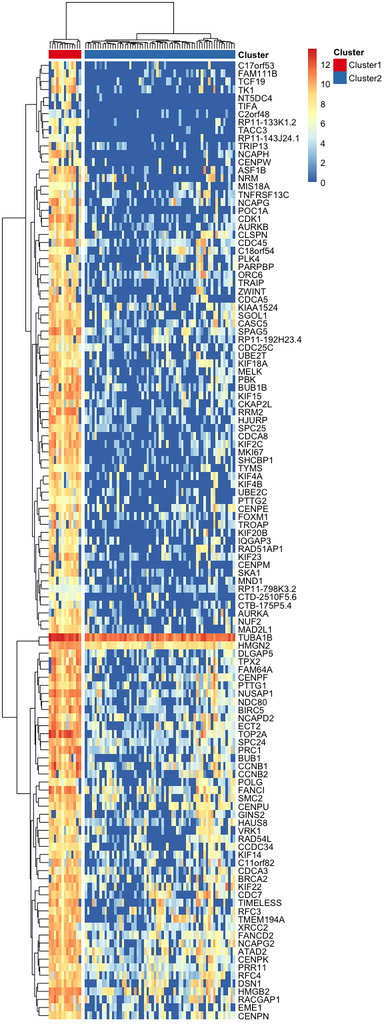

```r
pheatmap(log(marker.counts.SV1.long+1), show_colnames =FALSE,
         clustering_method = "ward.D2",cutree_cols = 2,annotation_col = anno.col2,
         annotation_colors = anno.colors)
```

```r
pheatmap(log(marker.counts.SV1.long+1), show_colnames =FALSE,
         clustering_method = "ward.D2",cutree_cols = 2,annotation_col = anno.col2,
         annotation_colors = anno.colors,
         filename=paste0("Patel_Glioblastoma_MGH30_iasva_SV1_genes_rsqcutoff0.3_pheatmap_iasvaV0.95_Figure3F.pdf"),
         width=6, height=16)
```

```r
write.table(as.data.frame(rownames(marker.counts.SV1)),
            file=paste0("Patel_Glioblastoma_MGH30_Cellcycle_SV1_Genes_rsqcutoff0.4.txt"),
            quote=F, row.names=F, col.names=F, sep=" ")

write.table(as.data.frame(rownames(marker.counts.SV1.long)),
            file=paste0("Patel_Glioblastoma_MGH30_Cellcycle_SV1_Genes_rsqcutoff0.3.txt"),
            quote=F, row.names=F, col.names=F, sep=" ")
```